# Read mapping and visualisation

## Adding the contig borders

Lastly, it would be nice to add the contig borders to the plot. You have looked at the contig lengths in R before, when you did the contig filtering. Indeed, we can use the same package `Biostrings` to read in the fasta file you used to perform the read mapping.

```r
library(Biostrings)
```

Now we need the fasta file, which we copy to our local folder (with the others files and to which you have set your working directory) once more using the `scp` command.

```bash
scp <yourusername>@curnagl.dcsr.unil.ch:<path/to/file/03_<ESL0xxx>_contigs_filtered.fasta /path/to/copy/to
```

We read in the fasta file as before:

```r
contigs <- readDNAStringSet("03_<ESL0xxx>_contigs_filtered.fasta")
contigs
```

```
## DNAStringSet object of length 104:
##        width seq                                            names
##   [1] 338569 ATGAGCTTGATTACTTTAGTCT...AGACAGTGGCAGGCGCCTGCG NODE_1_length_338...
##   [2] 262063 GGGTGTTAGTCTGAGAGTGGGT...TCTGGGGTGGTGATCGCGTTT NODE_2_length_262...
##   [3] 230198 CGGCCGTGAATGACCGCACAGG...TCGGGTGATAGGCGTGGCAAA NODE_3_length_230...
##   [4] 118569 TACGAATATCAACCAACACATC...TACGTCTGGGACGATGGTTCA NODE_4_length_118...
##   [5] 112130 ACTCGTTCGACTTGCATGTATT...TTTATCAGACATAATTAAGTG NODE_5_length_112...
##   ...    ... ...
## [100]    600 AGGCGTGGCAAAAGTAAACCGG...TGGCGCAGTAATCACCTTCAG NODE_101_length_6...
## [101]    590 TGACTGTCTGAGTAACAGAACT...TTATCAGGAGCTGCTTGTGAA NODE_102_length_5...
## [102]    572 AGAAGCAAGCTTCTCGGTTTGG...TACGACTTCACCCTAATCATT NODE_103_length_5...
## [103]    513 ATTATAGCTAATATCACCTTTC...TCCCATGGCCATTATAACCTT NODE_104_length_5...
## [104]    510 CGGCATCAAGACAGATAAACGA...TGATATTATGGTCTGGTATTC NODE_105_length_5...
```

Remember, we can simply extract the contig lengths with the function `width()`.

```r
# contig lengths:
width(contigs)
```

```
##   [1] 338569 262063 230198 118569 112130 111275 108552 105842 103187  96021
##  [11]  89085  81067  79716  67384  65767  65365  60540  52740  51030  50130
##  [21]  49555  43302  41353  36688  36231  34431  32109  28953  25348  24909
##  [31]  24536  23743  21399  21058  19539  18511  18287  18208  17565  16618
##  [41]  15620  15536  14857  14442  13536  11593  11522  11516  10288   9978
##  [51]   9464   7242   6524   6486   6272   6097   5955   5873   5745   5666
##  [61]   4603   4517   3952   3627   3227   3226   3015   2996   2887   2867
##  [71]   2769   2565   2397   2306   2284   1933   1931   1805   1700   1672
##  [81]   1639   1579   1493   1421   1416   1369   1351   1139   1021    961
##  [91]    950    821    751    740    725    679    654    650    639    600
## [101]    590    572    513    510
```

However, what we need, is the sequential addition of the contig lengths for our plot: the cumulative sums ($contig_1, \, contig_1 + contig_2, \, contig_1 + contig_2 + contig_3, \, etc.$). This we can get with the base function `cumsum()`.

```r
# cumulative sums of lengths:
cumsum(width(contigs))
```

```
##   [1]  338569  600632  830830  949399 1061529 1172804 1281356 1387198 1490385
##  [10] 1586406 1675491 1756558 1836274 1903658 1969425 2034790 2095330 2148070
##  [19] 2199100 2249230 2298785 2342087 2383440 2420128 2456359 2490790 2522899
##  [28] 2551852 2577200 2602109 2626645 2650388 2671787 2692845 2712384 2730895
##  [37] 2749182 2767390 2784955 2801573 2817193 2832729 2847586 2862028 2875564
##  [46] 2887157 2898679 2910195 2920483 2930461 2939925 2947167 2953691 2960177
##  [55] 2966449 2972546 2978501 2984374 2990119 2995785 3000388 3004905 3008857
##  [64] 3012484 3015711 3018937 3021952 3024948 3027835 3030702 3033471 3036036
##  [73] 3038433 3040739 3043023 3044956 3046887 3048692 3050392 3052064 3053703
##  [82] 3055282 3056775 3058196 3059612 3060981 3062332 3063471 3064492 3065453
##  [91] 3066403 3067224 3067975 3068715 3069440 3070119 3070773 3071423 3072062
## [100] 3072662 3073252 3073824 3074337 3074847
```

Lastly, we want to plot again in kbp instead of bp, so we once more divide by 1000.

```r
# cumulative sums in kb
contig_borders <- cumsum(width(contigs)) / 1000
contig_borders
```

```
##   [1]  338.569  600.632  830.830  949.399 1061.529 1172.804 1281.356 1387.198
##   [9] 1490.385 1586.406 1675.491 1756.558 1836.274 1903.658 1969.425 2034.790
##  [17] 2095.330 2148.070 2199.100 2249.230 2298.785 2342.087 2383.440 2420.128
##  [25] 2456.359 2490.790 2522.899 2551.852 2577.200 2602.109 2626.645 2650.388
##  [33] 2671.787 2692.845 2712.384 2730.895 2749.182 2767.390 2784.955 2801.573
##  [41] 2817.193 2832.729 2847.586 2862.028 2875.564 2887.157 2898.679 2910.195
##  [49] 2920.483 2930.461 2939.925 2947.167 2953.691 2960.177 2966.449 2972.546
##  [57] 2978.501 2984.374 2990.119 2995.785 3000.388 3004.905 3008.857 3012.484
##  [65] 3015.711 3018.937 3021.952 3024.948 3027.835 3030.702 3033.471 3036.036
##  [73] 3038.433 3040.739 3043.023 3044.956 3046.887 3048.692 3050.392 3052.064
##  [81] 3053.703 3055.282 3056.775 3058.196 3059.612 3060.981 3062.332 3063.471
##  [89] 3064.492 3065.453 3066.403 3067.224 3067.975 3068.715 3069.440 3070.119
##  [97] 3070.773 3071.423 3072.062 3072.662 3073.252 3073.824 3074.337 3074.847
```

And again, we can add these to our plots

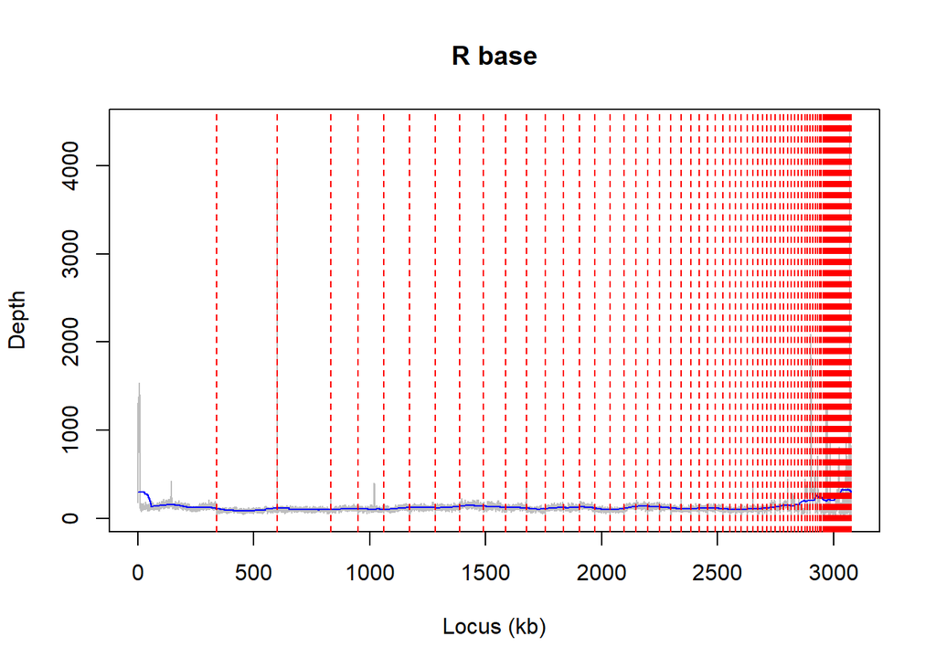

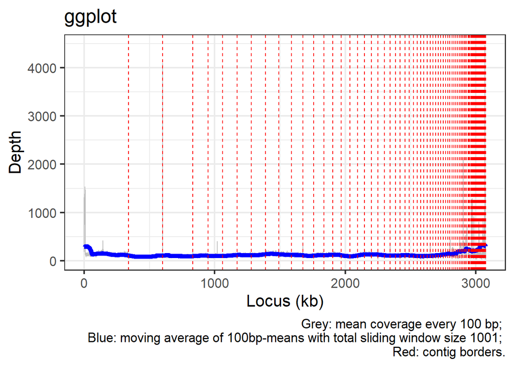

```r
# base R
plot(Depth ~ LocusKB,
     data = my_cov_bin,
     type = 'l',
     xlab = "Locus (kb)",
     col = "grey",
     main = "R base")
lines(SlidingAverage ~ LocusKB,
      data = my_cov_bin,
      col = 'blue')
abline(v = contig_borders, # adds a vertical line at x-coordinates v
       col = "red",
       lty = 2)

# ggplot
ggplot(my_cov_bin, aes(x = LocusKB, y = Depth)) +
  geom_line(col = "grey") +
  geom_line(aes(y = SlidingAverage), col = "blue", size = 2) +
  geom_vline(xintercept = contig_borders, col = "red", lty = 2) +
  labs(title = "ggplot",
       x = "Locus (kb)",
       caption = "Grey: mean coverage every 100 bp; \n Blue: moving average of 100bp-means with total sliding window size 1001; \n Red: contig borders.") +
  theme_bw(base_size = 16)
```

### Exercise 2.5: Adding contig borders

**Remember to write your code in your new R script *readcoverage.R*. Save it every now and then and run your code from there.**

1. Copy your file *03_<ESL0xxx>_contigs_filtered.fasta* from curnagl to your local computer, current working directory, using the `scp` command in the terminal.
2. Read this file into R in an object called `contigs`, like above.
3. Run `cumsum(width(contigs))`, `sum(width(contigs))` and `nrow(my_cov)`.
   - Do you understand what each of these three pieces of code do?
   - Compare their output: are they similar? Does that make sense? Why? Why not?
4. Calculate the contig borders using `cumsum()`, as in the example above and also save it into an object called `contig_borders`.
5. Add the contig borders as vertical lines to the plot you made in the previous exercise, as in the example above.

> Take some time looking at the coverage plot, and discuss it with your assistant. Are there any contigs with unusually high coverage? Or do you have sudden shifts in coverage within contigs? What could be the reason? If anything pops up, you could try to do some blasting.

Now you have your code saved in your script, so if you want to run it again in the exact same way next year, with the same parameters, you can. You should also save the plot you made to a file, e.g. png or pdf. The easiest way to do this, is probably to click in the Plots Pane on *Export > Save as Image/PDF*.